# Loss Distributions

- Simulation with `base` functions
- Visualize data
- Fit distributions
- Goodness of fit

# Packages we’ll use

- `MASS` (MASS = Modern Applied Statistics in S)
  - `fitdistr` will fit a distribution to a loss distribution function
- `actuar`
  - `emm` calculates empirical moments
  - `lev` limited expected value
  - `coverage` modifies a loss distribution for coverage elements
  - Contains many more distributions than are found in `base` R such as Burr, Pareto, etc. Basically, anything in “Loss Models” is likely to be found here.
  - Contains the dental claims data from “Loss Models”
- Direct optimization
  - `optim` function

# Statistical distributions in R

Function names are one of ‘d’, ‘p’, ‘q’, ‘r’ + function name

- d - probability density
- p - cumulative distribution function
- q - quantiles
- r - random number generator

# Examples

```r
mu <- 10000
CV <- 0.30
sd <- mu * CV
x <- seq(mu - sd*3, mu + sd * 3, length.out = 20)
p <- seq(.05, .95, by = .05)

dnorm(x, mu, sd)
```

```
##  [1] 1.477283e-06 3.624482e-06 8.048577e-06 1.617645e-05 2.942646e-05
##  [6] 4.844888e-05 7.219719e-05 9.737506e-05 1.188683e-04 1.313334e-04
## [11] 1.313334e-04 1.188683e-04 9.737506e-05 7.219719e-05 4.844888e-05
## [16] 2.942646e-05 1.617645e-05 8.048577e-06 3.624482e-06 1.477283e-06
```

```r
pnorm(x, mu, sd)
```

```
##  [1] 0.001349898 0.003635066 0.008932096 0.020054161 0.041207522
##  [6] 0.077650730 0.134522788 0.214917602 0.317862557 0.437269873
## [11] 0.562730127 0.682137443 0.785082398 0.865477212 0.922349270
## [16] 0.958792478 0.979945839 0.991067904 0.996364934 0.998650102
```

```r
qnorm(p, mu, sd)
```

```
##  [1]  5065.439  6155.345  6890.700  7475.136  7976.531  8426.798  8844.039
##  [8]  9239.959  9623.016 10000.000 10376.984 10760.041 11155.961 11573.202
## [15] 12023.469 12524.864 13109.300 13844.655 14934.561
```

```r
rnorm(10, mu, sd)
```

```
##  [1]  2567.301  5228.918 12883.180 10195.183 13112.059 10473.571 12064.597
##  [8] 14110.370  9806.088 12075.290
```

```r
dlnorm(x, log(mu), log(sd))
```

```
##  [1] 4.780950e-05 2.505870e-05 1.700824e-05 1.287673e-05 1.035979e-05
##  [6] 8.664742e-06 7.445171e-06 6.525483e-06 5.807122e-06 5.230481e-06
## [11] 4.757380e-06 4.362230e-06 4.027237e-06 3.739640e-06 3.490050e-06
## [16] 3.271406e-06 3.078292e-06 2.906489e-06 2.752656e-06 2.614119e-06
```

```r
plnorm(x, log(mu), log(sd))
```

```
##  [1] 0.3868287 0.4190398 0.4384745 0.4524493 0.4633699 0.4723339 0.4799359
##  [8] 0.4865345 0.4923631 0.4975820 0.5023061 0.5066205 0.5105903 0.5142660
## [15] 0.5176879 0.5208885 0.5238944 0.5267278 0.5294071 0.5319482
```

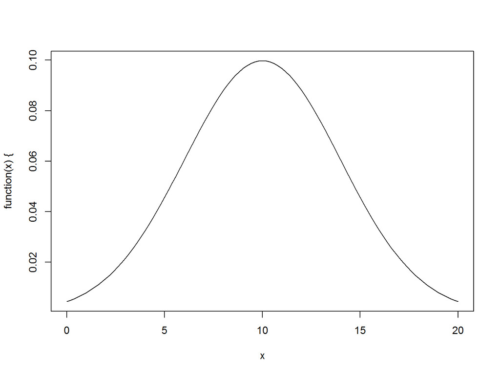

```r
plot(function(x) {dnorm(x, 10, 4)}, 0, 20)
```

# Generate some loss data

```r
set.seed(8910)
years <- 2001:2010
frequency <- 1000

N <- rpois(length(years), frequency)

sevShape <- 2
sevScale <- 1000
severity <- rgamma(sum(N), sevShape, scale = sevScale)

summary(severity)
```

```
##     Min.  1st Qu.   Median     Mean  3rd Qu.     Max.
##    21.93   928.90  1640.00  1970.00  2676.00 11130.00
```

# Histograms

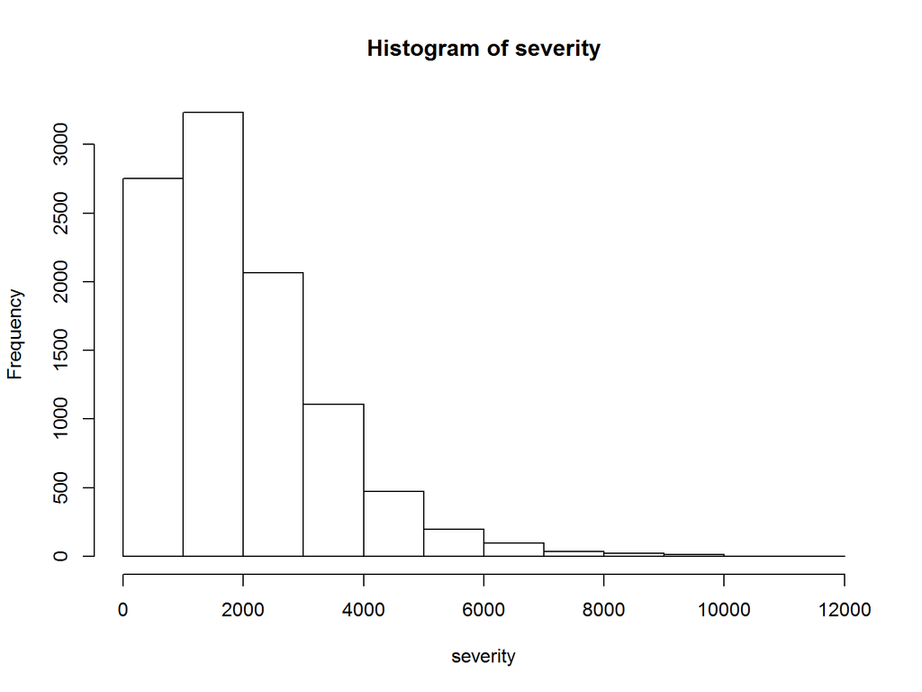

```r
hist(severity)
```

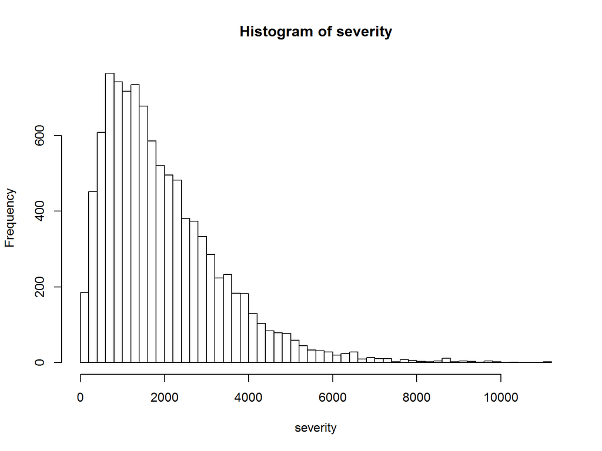

```r
hist(severity, breaks = 50)
```

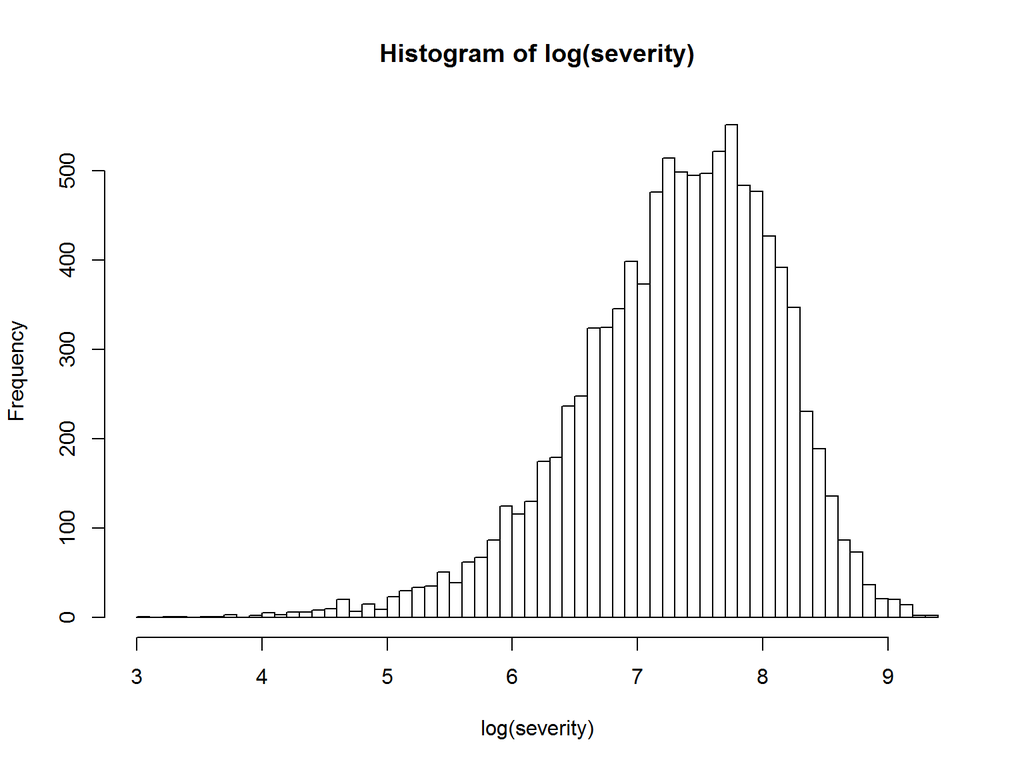

```r
hist(log(severity), breaks = 50)
```

# Density

The kernel density is effectively a smoothed histogram.

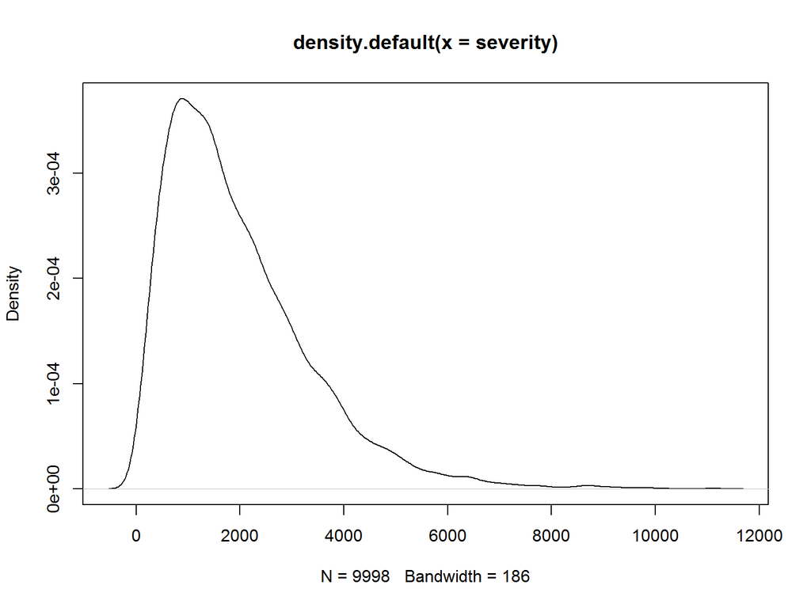

```r
plot(density(severity))
```

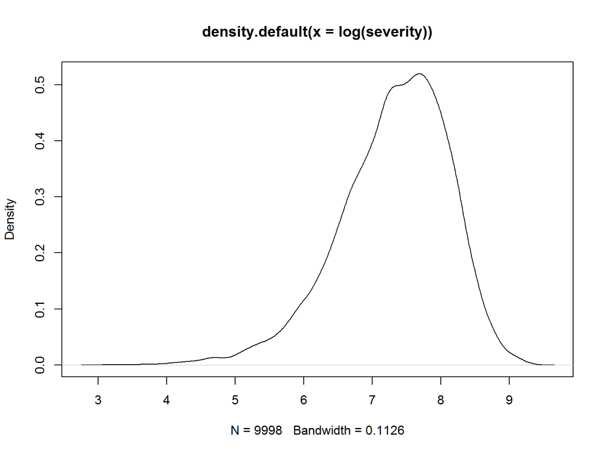

```r
plot(density(log(severity)))
```

# `fitdistr`

```r
library(MASS)

fitGamma <- fitdistr(severity, "gamma")
fitLognormal <- fitdistr(severity, "lognormal")
fitWeibull <- fitdistr(severity, "Weibull")
fitGamma
```

```
##       shape           rate
##   1.981942e+00   1.006292e-03
##  (1.261418e-02) (8.096328e-07)
```

```r
fitLognormal
```

```
##      meanlog        sdlog
##   7.312554108   0.804493446
##  (0.008045739) (0.005689197)
```

```r
fitWeibull
```

```
##       shape          scale
##   1.472049e+00   2.184117e+03
##  (1.117737e-02) (1.566082e+01)
```

# q-q plot

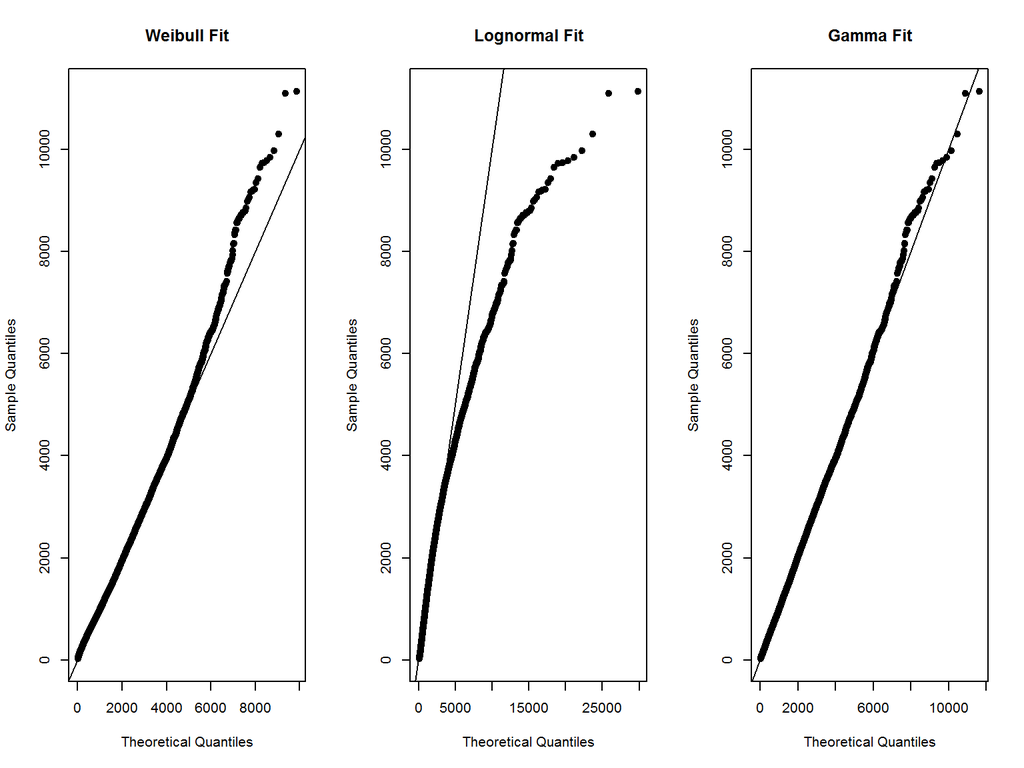

```r
probabilities = (1:(sum(N)))/(sum(N)+1)

weibullQ <- qweibull(probabilities, coef(fitWeibull)[1], coef(fitWeibull)[2])
lnQ <- qlnorm(probabilities, coef(fitLognormal)[1], coef(fitLognormal)[2])
gammaQ <- qgamma(probabilities, coef(fitGamma)[1], coef(fitGamma)[2])

sortedSeverity <- sort(severity)
oldPar <- par(mfrow = c(1,3))
plot(sort(weibullQ), sortedSeverity, xlab = 'Theoretical Quantiles', ylab = 'Sample Quantiles', pch=19, main = "Weibull Fit")
abline(0,1)

plot(sort(lnQ), sortedSeverity, xlab = 'Theoretical Quantiles', ylab = 'Sample Quantiles', pch=19, main = "Lognormal Fit")
abline(0,1)

plot(sort(gammaQ), sortedSeverity, xlab = 'Theoretical Quantiles', ylab = 'Sample Quantiles', pch=19, main = "Gamma Fit")
abline(0,1)
```

```r
par(oldPar)
```

# Compare fit to histogram

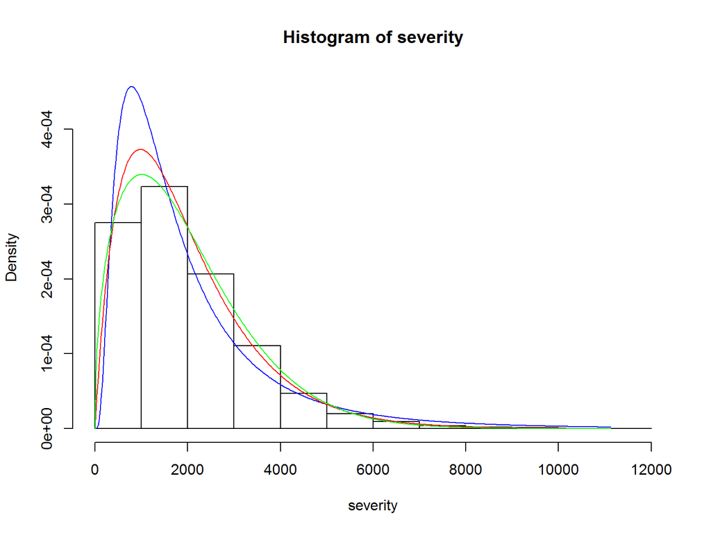

```r
sampleLogMean <- fitLognormal$estimate[1]
sampleLogSd <- fitLognormal$estimate[2]

sampleShape <- fitGamma$estimate[1]
sampleRate <- fitGamma$estimate[2]

sampleShapeW <- fitWeibull$estimate[1]
sampleScaleW <- fitWeibull$estimate[2]

x <- seq(0, max(severity), length.out=500)
yLN <- dlnorm(x, sampleLogMean, sampleLogSd)
yGamma <- dgamma(x, sampleShape, sampleRate)
yWeibull <- dweibull(x, sampleShapeW, sampleScaleW)

hist(severity, freq=FALSE, ylim=range(yLN, yGamma))

lines(x, yLN, col="blue")
lines(x, yGamma, col="red")
lines(x, yWeibull, col="green")
```

# Kolmogorov-Smirnov

The Kolmogorov-Smirnov test measures the distance between an sample distribution and a candidate loss distribution. More formal than q-q plots.

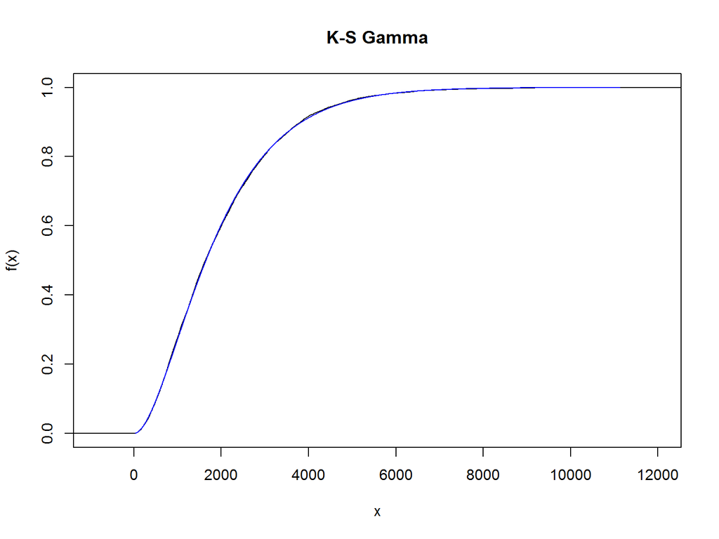

```r
sampleCumul <- seq(1, length(severity)) / length(severity)
stepSample  <- stepfun(sortedSeverity, c(0, sampleCumul), f = 0)
yGamma <- pgamma(sortedSeverity, sampleShape, sampleRate)
yWeibull <- pweibull(sortedSeverity, sampleShapeW, sampleScaleW)
yLN <- plnorm(sortedSeverity, sampleLogMean, sampleLogSd)

plot(stepSample, col="black", main = "K-S Gamma")
lines(sortedSeverity, yGamma, col = "blue")
```

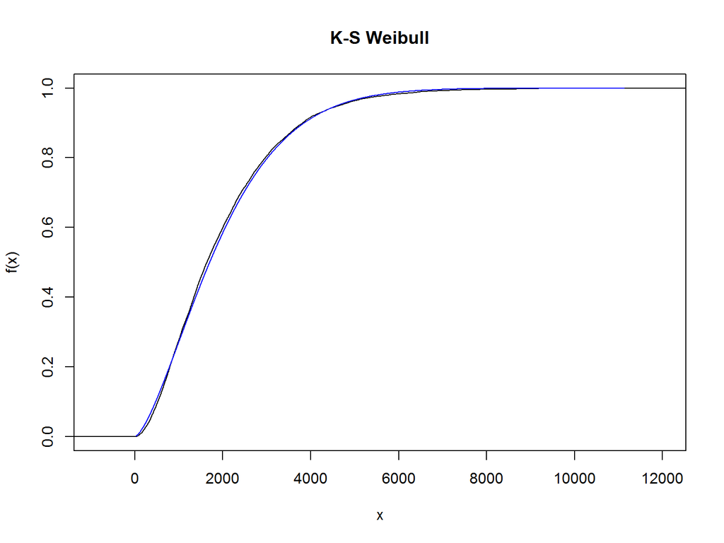

```r
plot(stepSample, col="black", main = "K-S Weibull")
lines(sortedSeverity, yWeibull, col = "blue")
```

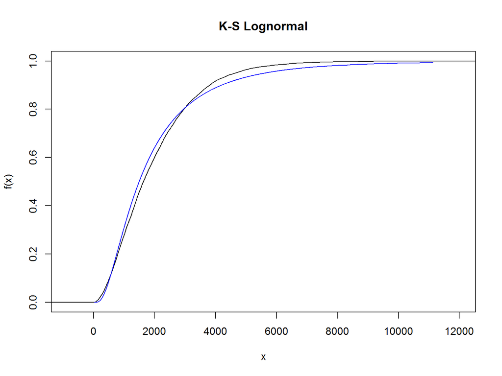

```r
plot(stepSample, col="black", main = "K-S Lognormal")
lines(sortedSeverity, yLN, col = "blue")
```

# More K-S

A low value for D indicates that the selected curve is fairly close to our data. The p-value indicates the chance that D was produced by the null hypothesis.

```r
testGamma <- ks.test(severity, "pgamma", sampleShape, sampleRate)
testLN <- ks.test(severity, "plnorm", sampleLogMean, sampleLogSd)
testWeibull <- ks.test(severity, "pweibull", sampleShapeW, sampleScaleW)

testGamma
```

```
##
##  One-sample Kolmogorov-Smirnov test
##
## data:  severity
## D = 0.0066186, p-value = 0.7735
## alternative hypothesis: two-sided
```

```r
testLN
```

```
##
##  One-sample Kolmogorov-Smirnov test
##
## data:  severity
## D = 0.047763, p-value < 2.2e-16
## alternative hypothesis: two-sided
```

```r
testWeibull
```

```
##
##  One-sample Kolmogorov-Smirnov test
##
## data:  severity
## D = 0.02053, p-value = 0.0004373
## alternative hypothesis: two-sided
```

# Direct optimization

The `optim` function will optimize a function. Works very similar to the Solver algorithm in Excel. `optim` takes a function as an argument, so let’s create a function.

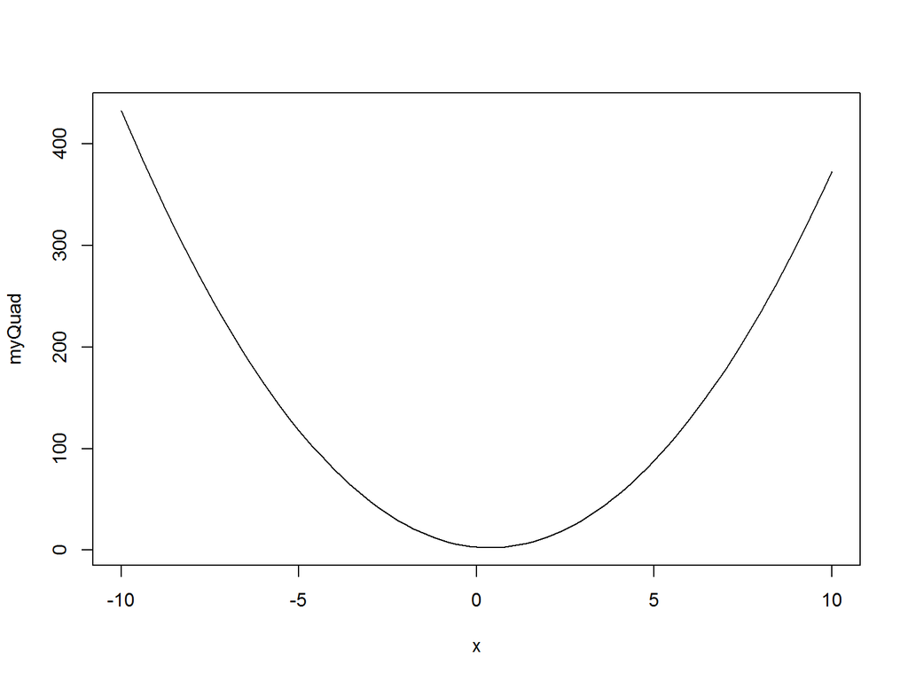

```r
quadraticFun <- function(a, b, c){
  function(x) a*x^2 + b*x + c
}

myQuad <- quadraticFun(a=4, b=-3, c=3)
plot(myQuad, -10, 10)
```

# Direct optimization

8 is our initial guess. A good initial guess will speed up conversion.

```r
myResult <- optim(8, myQuad)
myResult
```

[output not shown]

## Direct optimization

Default is to minimize. Set the parameter `fnscale` to something negative to convert to a maximization problem.

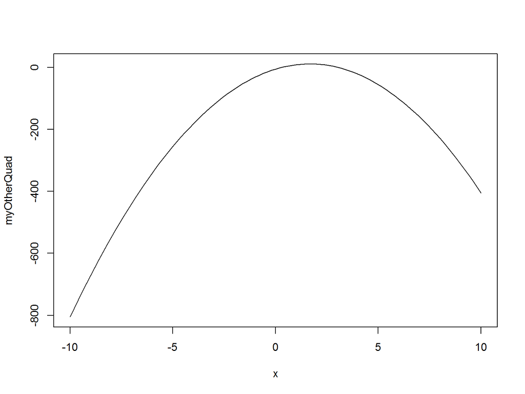

```r
myOtherQuad <- quadraticFun(-6, 20, -5)
plot(myOtherQuad, -10, 10)
```

```r
myResult <- optim(8, myOtherQuad)
myResult <- optim(8, myOtherQuad, control = list(fnscale=-1))
```

# Direct optimization

Direct optimization allows us to create another objective function to maximize, or work with loss distributions for which there isn’t yet support in a package like `actuar`. May be used for general purpose optimization problems, e.g. maximize rate of return for various capital allocation methods.

Note that optimization is a general, solved problem. Things like the simplex method already have package solutions in R. You don’t need to reinvent the wheel!

# Questions

- Plot a lognormal distribution with a mean of $10,000 and a CV of 30%.
- For that distribution, what is the probability of seeing a claim greater than $100,000?
- Generate 100 and 1,000 observations from that distribution.
- Draw a histogram for each sample.
- What are the mean, standard deviation and CV of each sample?
- Convince yourself that the sample data were not produced by a Weibull distribution.
- Assuming that losses are Poisson distributed, with expected value of 200, estimate the aggregate loss distribution.
- What is the cost of a $50,000 xs $50,000 layer of reinsurance?

# Answers

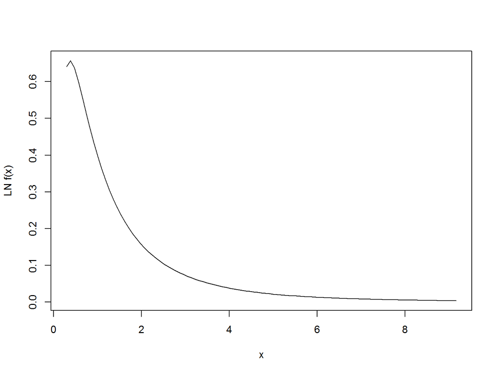

```r
severity <- 10000
CV <- .3
sigma <- sqrt(log(1 + CV^2))
mu <- log(severity) - sigma^2/2
plot(function(x) dlnorm(x), mu, sigma, ylab="LN f(x)")
```

# What am I?

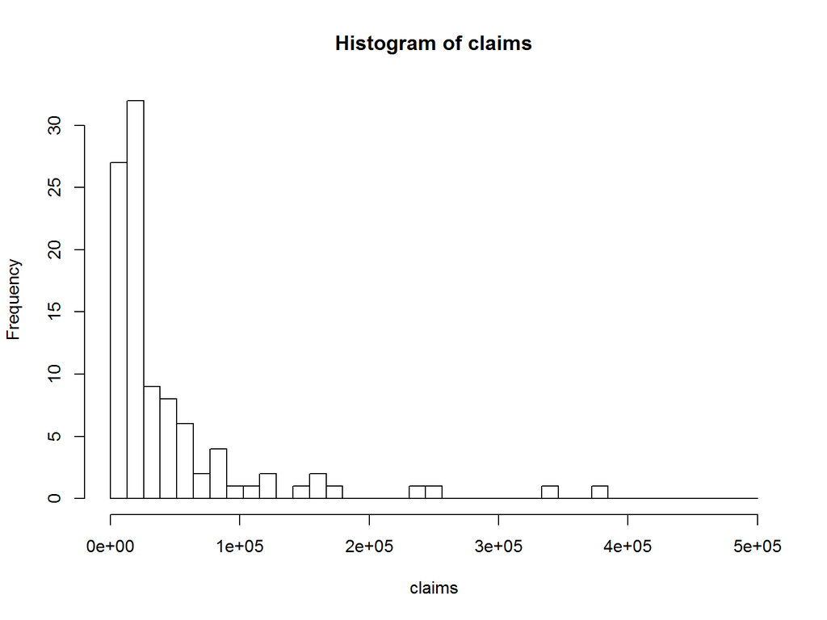

```r
set.seed(1234)
claims = rlnorm(100, meanlog=log(30000), sdlog=1)
hist(claims, breaks=seq(1, 500000, length.out=40))
```